# Data Understanding - Cluster Analysis on Opinions of Animal Welfare

James Smith

14 May 2019

Welcome all to the first installment of a *Cluster Analysis of Opinions on Animal Welfare*. This project is broken into several parts.

1. Data Understanding
2. Data Exploration
3. Data Quality
4. Dimensionality Reduction
5. Cluster Analysis

[figure not shown]

# Introduction

Animal welfare can oftentimes be a contentious topic of discussion. Opinions towards the welfare of animals can vary drastically, with some individuals fervently striving to help improve conditions through activism, personal choices etc. and others who may strongly oppose this. The behaviour, attitudes and opinions of people are complex and multi-faceted with many factors at play. The aim of this paper is to explore and analyse questionnaire data relating to peoples’ opinions and attitudes towards animal welfare and to investigate whether there is a natural way of grouping individuals together. Much like how companies find ways, we aim to do the same with regards to how people think about animal welfare.

The dataset we will be looking at is the *Animal Tracker* dataset, which is an annual survey that began in 2008 which aims to capture the opinions and attitudes of U.S. adults with respect to animal rights and related issues. The survey was funded by [Faunalytics](https://faunalytics.org/about/), a `non-profit research organisation’ that conducts studies and provides useful information to help animal welfare advocates.

# Loading the Data

The dataset and supplementary information used for this project can be found in Faunalytics’ public Google Drive [folder](https://drive.google.com/drive/folders/1tzr21r8jNCVYlTTT6vYhP2FbvW8xvkpt). The *Merged Animal Tracker Dataset (Waves 1 - 11) - value labels* csv file contains the labeled version of the dataset.

Let’s first load some packages

```r
# Load packages
library(tidyverse)
library(knitr)

# To clean workspace
rm(list=ls())
```

We have our data downloaded and unzipped in a folder titled `data` in the same directory as this markdown file. In order to avoid hardcoding file paths we can use `dirname(rstudioapi::getActiveDocumentContext()$path)` to get the folder that this file is located in (providing you are using rstudio and not plain-ol-R/R-Markdown). We’ll create a function to do this so that it can be re-used to obtain other files later on. Note that the `.xlsx` files are saved as csv’s beforehand to avoid java errors.

**Note:** R Markdown documents are rendered in a separate R session that doesn’t have access to the rstudioapi. Thus, the first line in the below cell won’t work if Knitting in R Markdown

## Survey Data

```r
#master_folder <- dirname(rstudioapi::getActiveDocumentContext()$path)

master_folder <- "C:/Users/User/Documents/Data Science/R/Animal Tracker/1_Understanding"

data_folder_name <- "Data"

data_labels <- "Merged Animal Tracker Dataset (Waves 1 - 11) - value labels.csv"

get_data <- function(master_folder, data_folder_name, filename){
  data_location <- paste(master_folder, data_folder_name, filename, sep = "/")
  return(read.csv(data_location))
}
```

```r
mydata <- get_data(master_folder, data_folder_name, data_labels)
colnames(mydata)
```

```
##   [1] "ATWAVE"          "ATWAVESCOMBINED" "ATUNIQUEID"
##   [4] "ATCASEID"        "ATWEIGHT"        "AGE"
##   [7] "EDUC"            "ETHNIC"          "GENDER"
##  [10] "HHHEAD"          "HHSIZE"          "HOUSING"
##  [13] "HHINCOME"        "MARITAL"         "MSA"
##  [16] "REG4"            "RENT"            "HHAGE1"
##  [19] "HHAGE2"          "HHAGE3"          "HHAGE4"
##  [22] "HHAGE5"          "WORK"            "INTERNET"
##  [25] "PET_CAT"         "PET_DOG"         "PET_FISH"
##  [28] "PET_BIRD"        "PET_GERBIL"      "PET_REPTILE"
##  [31] "PET_HORSE"       "PET_OTHER"       "PET_ALL"
##  [34] "AT1_1"           "AT1_2"           "AT1_3"
##  [37] "AT1_4"           "AT1_5"           "AT1_6"
##  [40] "AT1_7"           "AT1_8"           "AT2_1"
##  [43] "AT2_2"           "AT2_3"           "AT2_4"
```

[output cut: 30 more lines]

The ATWAVESCOMBINED column gives the number of participants for a given Wave/Year. This will useful later on when we want to filter for a given year.

```r
summary(mydata$ATWAVESCOMBINED)
```

```
##       Wave 10 2017       Wave 11 2018        Wave 2 2009
##               1004               1001               1000
##        Wave 3 2010        Wave 4 2011        Wave 5 2012
##               1020               1252               1072
##        Wave 6 2013        Wave 7 2014        Wave 8 2015
##               1028               1028               1009
##        Wave 9 2016 Waves 1 & 1.5 2008
##               1019               1554
```

There are a lot of variables that begin with AT (id’s and questions). Let’s remove AT variables and give a summary of the other more explanatory variables.

```r
summary(mydata %>% select(everything(), - starts_with("AT")))
```

```
##       AGE                                EDUC
##  Min.   :18.0   Bachelor's degree or higher:3870
##  1st Qu.:34.0   High school                :3642
##  Median :49.0   Less than high school      :1150
##  Mean   :47.8   Some college               :3325
##  3rd Qu.:60.0
##  Max.   :96.0
##
##                     ETHNIC        GENDER     HHHEAD         HHSIZE
##  2+ Races, Non-Hispanic: 391   Female:6037   No :2446   2      :4468
##  Black, Non-Hispanic   : 982   Male  :5950   Yes:9541   1      :2240
##  Hispanic              :1283                            3      :2137
##  Other, Non-Hispanic   : 444                            4      :1804
##  White, Non-Hispanic   :8887                            5      : 788
##                                                         6      : 331
##                                                         (Other): 219
##                                               HOUSING
##  A building with 2 or more apartments             :1954
##  A mobile home                                    : 566
##  A one-family house attached to one or more houses: 950
##  A one-family house detached from any other house :8489
##  Boat, RV, van, etc.                              :  28
##
##
##                  HHINCOME                   MARITAL              MSA
##  $100,000 to $124,999:1314   Divorced           :1190   Metro      :5755
##  $60,000 to $74,999  :1295   Living with partner: 823   No response:5061
##  $50,000 to $59,999  :1057   Married            :6647   Non-Metro  :1171
##  $40,000 to $49,999  : 953   Never married      :2626
##  $75,000 to $84,999  : 855   Separated          : 199
##  $85,000 to $99,999  : 849   Widowed            : 502
##  (Other)             :5664
##         REG4
##  Midwest  :2879
##  Northeast:2243
##  South    :4153
##  West     :2712
##
##
##
```

[output cut: 33 more lines]

```
##  #NULL!     :   6   #NULL!     :   6   #NULL!     :   6
##  No         :6895   No         :7518   No         :7633
##  No response:4057   No response:4057   No response:4057
##  Yes        :1029   Yes        : 406   Yes        : 291
##
##
##
##       PET_REPTILE         PET_HORSE          PET_OTHER    PET_ALL
##  #NULL!     :   6   #NULL!     :   6   #NULL!     :   6   No :4599
##  No         :7707   No         :7757   No         :7651   Yes:7388
##  No response:4057   No response:4057   No response:4057
##  Yes        : 217   Yes        : 167   Yes        : 273
##
##
##
```

We can see that there are many `#NULL!` values in the dataset. We will treat these as no responses. If one removes the minus sign in the previous line, it’s also clear that there are a lot of `No response` entries for the questions. For now we will group `#NULL!` with `No response` to deal with later when handling missing values.

```r
mydata[mydata == '#NULL!'] <- "No response"
```

## Data Dictionary

Along with the dataset, there is an accompanying *Data Dictionary*, containing information on all variables and questions asked. Let’s take a look.

```r
# This assumes you save saved your .xlsx data dictionary as a .csv

dictionary = "Data Dictionary (Waves 1-11).csv"

get_dictionary <- function(master_folder, data_folder_name, filename){
  data_location <- paste(master_folder, data_folder_name, filename, sep = "/")
  # Skip first line
  return(read.csv(data_location, skip = 1))
}
```

Load the dictionary andview column names

```r
dictionary <- get_dictionary(master_folder, data_folder_name,dictionary)
head(dictionary, 3)
```

```
##     Variable.Name                              Variable.Label
## 1          ATWAVE                                        Wave
## 2 ATWAVESCOMBINED                      Waves 1 & 1.5 Combined
## 3      ATUNIQUEID Unique Case Identification across All Waves
##                                                                                                         Response.Labels..Note.that.999.includes.not.asked..not.applicable..refused..no.response.
## 1 1 = Wave 1 2008\n2 = Wave 1.5 2008\n3 = Wave 2 2009\n4 = Wave 3 2010\n5 = Wave 4 2011\n6 = Wave 5 2012\n7 = Wave 6 2013\n8 = Wave 7 2014\n9 = Wave 8 2015\n10 = Wave 9 2016\n11 = Wave 10 2017
## 2              1 = Waves 1 & 1.5 2008\n2 = Wave 2 2009\n3 = Wave 3 2010\n4 = Wave 4 2011\n5 = Wave 5 2012\n6 = Wave 6 2013\n7 = Wave 7 2014\n8 = Wave 8 2015\n9 = Wave 9 2016\n10 = Wave 10 2017
## 3                                                                                                                                                                                      [numeric]
##   X1.1.5..2008. X2..2009. X3..2010. X4..2011. X5..2012. X6..2013.
## 1             Y         Y         Y         Y         Y         Y
## 2             Y         Y         Y         Y         Y         Y
## 3             Y         Y         Y         Y         Y         Y
##   X7..2014. X8..2015. X9..2016. X10..2017. X11..2018.
## 1         Y         Y         Y          Y          Y
## 2         Y         Y         Y          Y          Y
## 3         Y         Y         Y          Y          Y
##                                                                                                                                 Additional.Notes.on.Variable
## 1
## 2
## 3 This variable was created when the wave files were merged. It has no inherent meaning, and simply provides a way of uniquely identifying individual cases.
##    X X.1 X.2 X.3 X.4 X.5 X.6 X.7 X.8 X.9 X.10
## 1 NA  NA  NA  NA  NA  NA  NA  NA  NA  NA   NA
## 2 NA  NA  NA  NA  NA  NA  NA  NA  NA  NA   NA
## 3 NA  NA  NA  NA  NA  NA  NA  NA  NA  NA   NA
```

Clearly there are many unessessary columns (X, X.1, X.2, … , X.10). Our aim is to find out what all the variables mean, namely the questions and when they were asked. We will rename some of the columns we’ll keep and remove those that are redundant.

```r
dictionary <- dictionary %>% dplyr::rename(variable_name = Variable.Name,
                                    variable_label = Variable.Label,
                                    response_label = Response.Labels..Note.that.999.includes.not.asked..not.applicable..refused..no.response.
                                    )
dictionary <- dictionary %>% select( -c("X", "X.1", "X.2", "X.3", "X.4", "X.5", "X.6", "X.7", "X.8", "X.9", "X.10"))
```

Find dimensions of dictionary

```r
dim(dictionary)
```

```
## [1] 998  15
```

998 rows seems like a lot, considering there are only 133 variable. Looking at rows 130 to row 140 using `dictionary[c(130:140),]` shows that there are empty rows beyond 133.

```r
dictionary <- dictionary %>% slice(1:133)
```

```r
dictionary[34:37,]
```

```
##    variable_name
## 34         AT1_1
## 35         AT1_2
## 36         AT1_3
## 37         AT1_4
##                                                                                               variable_label
## 34 [Animal protection] : What is your opinion of each of the following social causes or political movements?
## 35  [Environmentalism] : What is your opinion of each of the following social causes or political movements?
## 36 [Homeless advocacy] : What is your opinion of each of the following social causes or political movements?
## 37    [Workers rights] : What is your opinion of each of the following social causes or political movements?
##                                                                        response_label
## 34 1 = Favorable\n2 = Unfavorable\n3 = No opinion\n4 = Do not know\n999 = No response
## 35 1 = Favorable\n2 = Unfavorable\n3 = No opinion\n4 = Do not know\n999 = No response
## 36 1 = Favorable\n2 = Unfavorable\n3 = No opinion\n4 = Do not know\n999 = No response
## 37 1 = Favorable\n2 = Unfavorable\n3 = No opinion\n4 = Do not know\n999 = No response
##    X1.1.5..2008. X2..2009. X3..2010. X4..2011. X5..2012. X6..2013.
## 34             Y         Y         N         N         Y         N
## 35             Y         Y         N         N         Y         N
## 36             Y         Y         N         N         Y         N
## 37             Y         Y         N         N         Y         N
##    X7..2014. X8..2015. X9..2016. X10..2017. X11..2018.
## 34         N         Y         N          N          Y
## 35         N         Y         N          N          Y
## 36         N         Y         N          N          Y
## 37         N         Y         N          N          Y
##    Additional.Notes.on.Variable
## 34
## 35
## 36
## 37
```

We can see that the variable name `AT1_1` asks a general question but is then related to a specific example i.e

> What is your opinion of each of the following social causes or political movements?

is a general question (refered to as `AT1`) but it asks for the respondants opinion with respect to *[Animal protection]* (`AT1_1`), and *[Environmentalism]* (`AT1_2`).

### Cleaning the Dictionary

It is important to extract the main questions from their sub-questions for when we go to explore and analyse the data.

```r
spliting_questions = function(dictionary){

  # Convert variable labels to character
  dictionary$variable_label = as.character(dictionary$variable_label)
  # Lists all row indexes that contain the question divider
  divided_questions = c(grep(':', dictionary$variable_label))

  dict_divided_questions = dictionary[divided_questions,]
  dict_non_divided_questions = dictionary[-divided_questions, ]
  divided_questions = as.data.frame(t(data.frame(sapply(dict_divided_questions$variable_label, strsplit, split=':'))))
  divided_questions = divided_questions %>% dplyr::rename(sub_question = V1,
                                                 main_question = V2)
  dictionary_questions = cbind(dict_divided_questions, divided_questions)

  dict_non_divided_questions$sub_question = ""
  dict_non_divided_questions$main_question = dict_non_divided_questions$variable_label

  # Join back together
  dictionary = rbind(dict_non_divided_questions, dictionary_questions)

  return(dictionary)
}

dictionary = spliting_questions(dictionary)
```

We now have our cleaned questions!

# Transformations

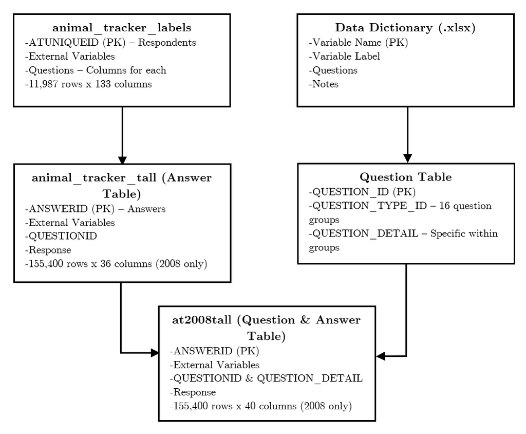

In practice, how do we impliment this?

Using the trusty `melt()` function in the package `reshape`. In order to have a question_id column we need to melt all the questino column into 1.

```r
library(reshape)
```

```r
# List columns we want to keep, will melt all others
id_columns = c("ATWAVE","ATWAVESCOMBINED","ATUNIQUEID","ATCASEID","ATWEIGHT","AGE","EDUC","ETHNIC","GENDER",
       "HHHEAD","HHSIZE","HOUSING","HHINCOME","MARITAL","MSA","REG4","RENT","HHAGE1","HHAGE2","HHAGE3",
       "HHAGE4","HHAGE5","WORK","INTERNET","PET_CAT","PET_DOG","PET_FISH","PET_BIRD","PET_GERBIL","PET_REPTILE",
       "PET_HORSE","PET_OTHER","PET_ALL")

wave = "Waves 1 & 1.5 2008"
wave_ind_column = "X1.1.5..2008." # Column to filter for questions that were asked

melt_data = function(mydata, wave){
  return(
    mydata %>%
     subset(ATWAVESCOMBINED == wave) %>%
      reshape::melt(id = id_columns) %>%
        dplyr::rename("ATTRIBUTEID" = variable, "RESPONSE" = value)
  )
}

mydata_long_2008 = melt_data(mydata, wave)
head(mydata_long_2008,2)
```

```
##        ATWAVE    ATWAVESCOMBINED ATUNIQUEID ATCASEID ATWEIGHT AGE
## 1 Wave 1 2008 Waves 1 & 1.5 2008          1       39     0.29  18
## 2 Wave 1 2008 Waves 1 & 1.5 2008          2      140     1.51  18
##           EDUC                 ETHNIC GENDER HHHEAD HHSIZE
## 1 Some college 2+ Races, Non-Hispanic Female     No      2
## 2 Some college    White, Non-Hispanic Female     No      5
##                                            HOUSING             HHINCOME
## 1 A one-family house detached from any other house $125,000 to $149,999
## 2 A one-family house detached from any other house   $75,000 to $84,999
##         MARITAL       MSA  REG4
## 1 Never married     Metro  West
## 2 Never married Non-Metro South
##                                                        RENT HHAGE1 HHAGE2
## 1 Owned or being bought by you or someone in your household      0      0
## 2 Owned or being bought by you or someone in your household      0      0
##   HHAGE3 HHAGE4 HHAGE5                                         WORK
## 1      0      0      2               Not working - looking for work
## 2      1      1      3 Not working - on temporary layoff from a job
##   INTERNET PET_CAT PET_DOG PET_FISH PET_BIRD PET_GERBIL PET_REPTILE
## 1      Yes     Yes     Yes       No       No         No          No
## 2      Yes     Yes     Yes      Yes       No        Yes          No
##   PET_HORSE PET_OTHER PET_ALL ATTRIBUTEID   RESPONSE
## 1        No        No     Yes       AT1_1  Favorable
## 2        No        No     Yes       AT1_1 No opinion
```

From here we can now join the dictionary table to our newly created question and response table

```r
dictionary = dictionary %>% dplyr::rename("ATTRIBUTEID" = variable_name)

merged = merge(mydata_long_2008, dictionary)

# Remove questions that were not asked for a given year
merged = merged[merged$"X1.1.5..2008." == "Y",]
```

From here we are just about ready to begin visualising our survey data for 2008. We will just need to save our table out as a csv to be picked up by Tableau.